# Chapter 13. Fatigue

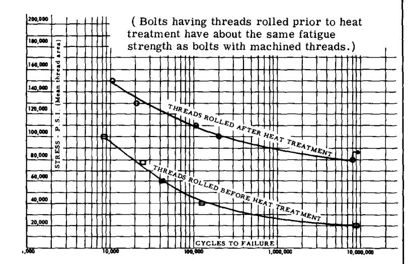

Fig. C13.24 - Thread Rolling

定義により、 $S_{min} = -23$ ksiとなり、これによって46 ksiの応力範囲が得られるが、これは目標とする値には及ばない。

**Step 5.** 再度、 $R = -2$ と仮定する。このとき、500,000サイクルに対する $S_{max}$ は18 ksiとなる。定義により、

$$S_{min} = -2 \times 18 = -36\text{ ksi}$$

対応する応力範囲は $18 - (-36) = 54$ ksiとなり、必要とされる値よりも大きくなる。これは、応力範囲が実際に51 ksiであり、 $-36$ ksiの残留応力が存在する場合、寿命が500,000サイクルよりも長くなることを示している。このとき $S_{max}$ は15 ksiとなる。

ショットピーニング業界は、材料の降伏強度の3分の2に達する高い残留応力を維持できると主張しているが、より保守的に2分の1という値をとる方が安全である。上記の $-36$ ksiは、十分に妥当な範囲内にある。51 ksiの応力範囲を使用すると、実際の寿命は200万サイクルをわずかに超えることになる（ $R = -2.4$ を参照）。

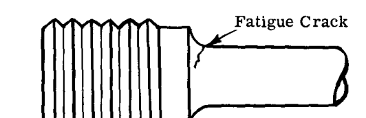

Fig. C13.25 - Fatigue failure at fillet

### 例題 (1)

図 C13.25は、試験中に50,000サイクルで破損したターンバックル組立部品の一部を示している。500,000サイクルの寿命が求められている。この部品がショットピーニングに適しており、図 C13.10のS-N曲線が適用可能であると仮定した場合、必要な寿命を確保するためにはどのような残留応力が必要か。荷重条件は $R = 0$ とする。

**Step 1.** $R = 0$ における50,000サイクルでの $S_{max}$ は51 ksiである。これは応力範囲でもあり、図 C13.10およびC13.9を参照されたい。

**Step 2.** $S_{max} - S_{min} = 51$ ksi の応力範囲（マイナスにマイナスを引くとプラスになる）。

**Step 3.** 未知数が2つで方程式が1つであるが、負の $R$ （ショットピーニングによって圧縮残留応力が導入されるため）における $S_{max}$ の値を仮定し、それに対応する最小応力を決定することができる。疲労は精密科学ではないことを念頭に置く必要がある。もし $S_{max} - S_{min}$ が51 ksiよりも大きくなれば、寿命は必要とされる500,000サイクルよりも長くなり、残留応力が緩和が問題とならない範囲にあれば好都合である。

**Step 4.** $R = -1$ と仮定する。500,000サイクルにおける $S_{max}$ は23 ksiであることがわかる。

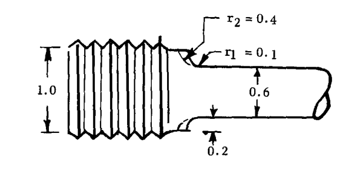

Fig. C13.26 - Fillet Revision

### 例題 (2)

図 C13.26は、前述の例で使用した部品と同じものであるが、適切な寸法が追加されている。元の部品が10,000サイクルしか持たず、500,000サイクルの寿命が必要であると仮定する。必要な寿命を得るためには、どのように対処すべきか。

**Step 2.** 明らかに、前の問題よりも多くの残留応力が必要であるため、直接 $R = -4$ に進むと、500,000サイクルで $S_{max}$ は12 ksiであることがわかる。 $S_{min}$ は $-4 \times 12 = -48$ ksiとなり、応力範囲は60 ksiとなるが、これは必要な74 ksiには及ばない。

たとえ $R = -8$ （ $S_{max} = 8$ ksi、 $S_{min} = -64$ ksi）まで進んだとしても、 $-64$ ksiの残留応力は、緩和のために維持できる限度を超えてしまう。

**Step 3.** では、どうすべきか。図の $r_2$ に示されているように、より緩やかな半径を設けることで応力集中を低減することを試みる。図 C13.8を参照すると、元の $K_t = 1.86$ は、

$$h/r = 2 \quad \left(\frac{0.2}{0.1} = 2\right)$$

の曲線に沿って見出される。

**Step 4.** 提案された構成に対して、

$$h/r = 0.2 / 0.4 = 0.5$$

および

$$r/d = 0.4 / 0.6 = 0.67$$

となり、これらから $h/r = 0.5$ および $r/d = 0.67$ の曲線に沿って $K_t = 1.26$ が得られる。

**Step 5.** 新しい応力範囲は、

$$74\text{ ksi} \times \frac{1.26}{1.86} = 50\text{ ksi}$$

となる。

**Step 6.** これで、扱うのに妥当な応力範囲が得られたため、前の例と全く同様に問題を処理する。

## A13.5.5 拡散硬化による残留応力

アルミニウム合金構造の疲労強度は、拡散硬化によって導入される残留応力による影響を受けないが、事実上すべての鋼材はこのような処理から利益を得るか、あるいは害を被る可能性がある。

表面窒化は、材料がコア（芯部）の過度な伸びを防ぐのに十分な厚さを持っている限り、常に表面に残留圧縮応力を生じさせる。中炭素鋼に特に適しているが、特殊合金である「Nitralloy」は、表面窒化を施すことで優れた疲労特性を示す（図 C13.27を参照）。また、窒化は優れた耐摩耗面も提供する。そのため、航空機におけるその用途は、フラップ軌道などのローラー面に適している。

浸炭、すなわち「ケースハードニング」は、鋼に優れた耐摩耗面をもたらす一方で、圧縮または引張の残留応力を導入する可能性がある。したがって、疲労防止策としての効果については疑問が残る。

クロムメッキは、ほぼ常に有害であるが、図 C13.28に示されているように、メッキを施す前にショットピーニングを行うことで、部品を元の疲労強度まで回復させることができる。(27) クロムメッキは耐摩耗性や耐食性のために広く使用されているが、メッキが疲労に影響しやすい隅肉半径などを覆う場合には注意が必要である。このようなケースでは、クロムメッキなしの状態でも、部品を疲労要件に適合させるためにショットピーニングが必要となる場合がある。したがって、強度を元の特性に戻すだけでは不十分であり、他の防錆剤に加えてショットピーニングが必要となる。疲労が重大な領域にはカドミウムメッキ（プラス、ショットピーニング）を施し、摩耗面のみにクロムを使用することが解決策となるかもしれない。一部の航空機メーカーは、隅肉の接点から1/8インチ以内へのクロムメッキを禁止している。

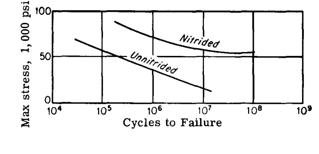

Fig. C13.27 - Effect of nitriding Nitralloy on the corrosion fatigue strength; rotating beam(26).

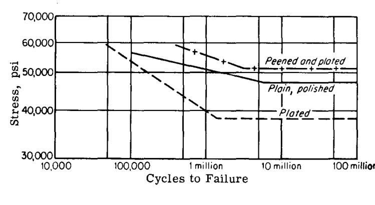

Fig. C13.28 - Rotating beam fatigue test results showing effect of chromium plating with and without shot peening.

Chrome-ite* は、0.0002インチ未満の厚さを持つ高密度クロムメッキの商標名である。通常のクロムメッキの有害な効果とは異なり、疲労寿命が向上する。図 C13.29は、160～180 ksiの範囲に熱処理された厚さ0.050インチの4130鋼製軸荷重試験片の比較寿命を示している。試験片の厚さが0.050インチにすぎないため、寿命を向上させるのに十分な残留圧縮応力を表面に付与するほどのコア厚さが確保されていたかは疑わしい。

アルミニウム合金に関する試験でも同様の改善が示されたが(28)、50 ksiを超える予荷重をかけると、すべての効果が失われた。図 C13.29に示されている予荷重をかけた1つの試験片は、鋼材に対して予荷重が有害な影響を与えることを示していない。

Chrome-iteは残留圧縮応力とはほとんど関係がないようであるが、残留圧縮応力が必須であるクロムメッキに関する議論に隣接させるために、この時点で含められた。なぜ疲労寿命が向上するのかについては、現時点では推測の域を出ないが、

- Chrome-ite Co.（カリフォルニア州ガーデナ）の商標名。

同様の改善は、試験片にケロシンや他の疎油性フィルムをコーティングすることによっても達成されている。(29)

### 圧縮残留応力による利点に関する議論

例題(1)では、R = 0における50,000サイクルの寿命に対応する最大応力がたまたま51 ksiであったため、応力集中部における最大応力を51 ksiと仮定した。これが真実であるのは、試験時に残留応力が存在しなかった場合に限られる。加工などによる残留圧縮応力が存在していた場合、ピーニングによる圧縮応力の増加は、ほとんど効果がないと考えられた。一方、残留引張応力が存在していた場合、ピーニングは引張応力を除去するだけでなく、好ましい圧縮応力を導入するため、例題(1)で推定されたよりもさらに寿命が向上することになる。

構造物に残留応力が存在するかどうかを常に判断できるわけではないが、引張-引張荷重において部品が10,000サイクル未満で破損した場合、何らかの塑性変形が存在していると確信できる。そのような場合、局部的な降伏によって残留引張応力は消失し、また、局部的な降伏によってある程度の残留圧縮応力が導入されることになる。これにより、ピーニングやその他の方法によって追加の残留圧縮応力を導入する効果は限定的になる。

例えば、元の部品が2500サイクルで破損し、例題(2)のように応力集中を低減する方法がなかったと仮定する。図 C13.19に示されている応力-ひずみ曲線を見ると、7075-T6の降伏強度は約75 ksiであったことがわかる。また、応力の著しい増加なしに、かなりの量のひずみが許容されることもわかる。

応力集中部における最大応力（2500サイクルの寿命に対応する）が76 ksiであったと仮定する。その理由は、これ以上の応力が加わると、全断面積が降伏するためである。しかし、この時点で、実際の応力が76、77、あるいは80 ksiであるかはそれほど重要ではない。なぜなら、最大応力が何であれ、最小応力はゼロではなく、何らかの負の値になるからである。これは、全断面が降伏した場合でも同様であり、弾性回復によって応力集中部に圧縮が生じるためである。

最大応力が76 ksiであったという仮定を継続すると、2500サイクルの寿命は、

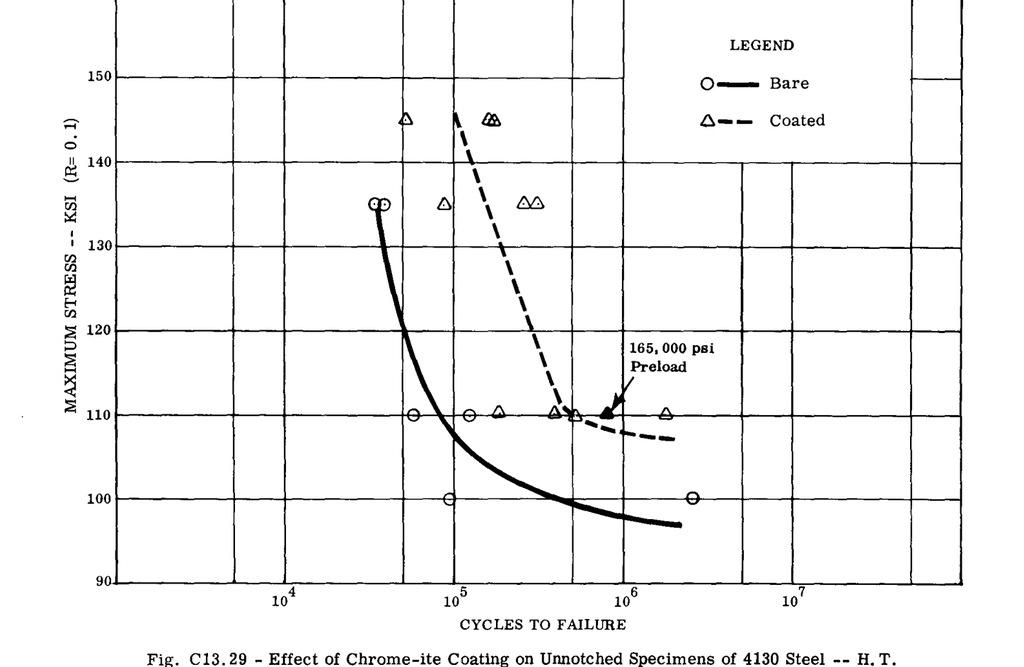

Fig. C13.29 - Effect of Chrome-ite Coating on Unnotched Specimens of 4130 Steel – H. T.

$R = -0.5$ （76 ksiにおける、図 C13.10を参照）のS-N曲線と交差する。これは、定義により、最小応力が $-0.5 \times 76\text{ ksi} = -38$ ksiになることを示している。さらに、ショットピーニングによって $-50$ ksiの圧縮応力が達成可能であると仮定する。全応力範囲は $76\text{ ksi} - (-38\text{ ksi}) = 114$ ksiであるため、ピーニングされた構造物の最大応力は、同じ荷重に対して $114 - 50\text{ ksi} = 64$ ksiとなる。対応する応力比は $-50/64 = -0.78$ となり、図 C13.10における寿命は約4000サイクル、すなわち元の寿命の2倍未満となる。

以上の点は、残留圧縮応力を導入することによって問題が解決できるかどうかを判断する際には、ある程度の注意が必要であることを示している。例題(1)では、寿命を10倍以上延ばすために必要な残留応力は、わずか $-36$ ksiであった。したがって、必要な寿命の増加が10倍以上である場合、表面の圧縮応力は、稼働中の最大応力が局部的な降伏を引き起こさない場合にのみ有効である。これは、荷重が一定振幅であるか変動振幅であるかに関わらず当てはまる。

上記のような冷間加工は、それ自体が材料特性の向上とみなされるかもしれないが、アルミニウム合金に関する試験ではこれが実証されていない。7075-T6のノッチなし試験片は、疲労試験の前に4%引き伸ばしても疲労寿命に変化は見られなかった。したがって、少なくとも熱処理可能なアルミニウム合金においては、冷間加工によって得られるあらゆる効果は、有益な残留応力によるものであると仮定できる。

## A13.5.6 剛性の向上

以下の議論は、構造物のばね定数を変更することにより、応力振幅を低減して疲労寿命を向上させることに関するものである。再び図 C13.10のS-N曲線を参照すると、 $R = +0.5$ の曲線が特に興味深い。ここでは、 $R = 0$ で荷重をかけたときに50,000サイクルしか持たない構造物でも、もし応力を $R = +0.5$ でサイクルさせることができれば、ほぼ無限に持たせることができることがわかる。換言すれば、最大応力が不変であるか、あるいはわずかに高くなったとしても、最小応力を「下支え」することができれば、疲労寿命は大幅に向上する。

ボルトの締め付けは、この「下支え」効果がどのように達成されるかを示す好例である。しかし、一般的には、使用応力よりも高い応力で締め付けられたボルトは、静的な状態を維持するというのが共通の認識である。実際に起こっていることは、締め付けられたボルトが当接材料の追加の剛性を利用して応力振幅を低減しているということである。

これは、図 C13.30に示されているようにサイクルするボルトを視覚化することによって、より容易に理解できる。ここに示されているサイクル振幅は、理解しやすいように誇張されている。

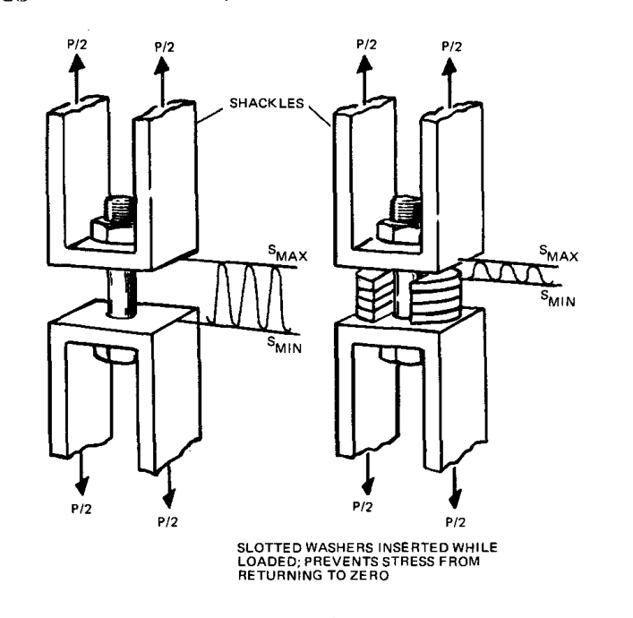

Fig. C13.30 - Analogy of Stress for Loose and Pretorqued Bolts

ここで、荷重が完全に加わった状態で、図 C13.30（右）に示されているように、隙間に割ワッシャーを挿入すると仮定する。ワッシャーは応力がゼロに戻るのを防止するが、ワッシャーとシャックルの間のクリアランスに示されているように、最大応力には影響を与えない。これが意味することは、ワッシャーがボルトの剛性を高めたため、図 C13.30（右）に示されている応力振幅は、ボルトの面積がワッシャーの断面積分だけ増加したのと全く同じになるということである。

ボルトは無負荷の状態でワッシャーに載っている間に引張応力を受けるため、無負荷でワッシャーに載っているときと同じ強さまでボルトを締め付けることによって、同じ効果を達成することができる。

より高い引張応力まで締め付けても、応力振幅はボルトの剛性と当接材料（この場合はシャックル）の組み合わせによって決定されるため、応力振幅は変化しない。しかし、最大応力は増加するため、適切に締め付けた場合と比較して、疲労寿命は低下することになる。

したがって、荷重が非常に高くない限り、極端に高いトルク値を使用する意味はない。これは、特定の荷重条件に対して最適なトルク値は1つしか存在しないことを意味する。図 C13.30に示されている例では、最適なトルク値は、荷重が完全に加わったときにシャックルが完全に浮き上がることを可能にする。

したがって、締め付けトルクによって、荷重による応力が増加することはない。

この疲労寿命を向上させるための剛性向上の原理は、しまりばめ（インターフェレンス・フィット）ファスナーにも適用される。しまりばめは、穴の周囲にそれ自体としては有害な残留引張応力を導入するが、ファスナーによって構造物に追加の剛性をもたらす。しまりばめファスナーは、無負荷時に応力を受けた材料が載るシート（受け座）として機能し、これはボルトの例におけるワッシャーの積層と非常によく似ている。

12 ksi（総面積応力、 $R = 0.1$ ）で試験されたラグのテーパーピンのしまり（干渉）と疲労寿命の関係を示すグラフを、図 C13.31に示す。0.0035インチのしまりを超えると、疲労寿命が低下することに注目されたい。これは、特定の荷重に対して1つのトルク値が最適であるという前述の記述と一致している。ラグは厚さ0.1インチの7075-T6、幅1.31インチで、3/8インチ径のテーパーピンを介して荷重が加えられた。

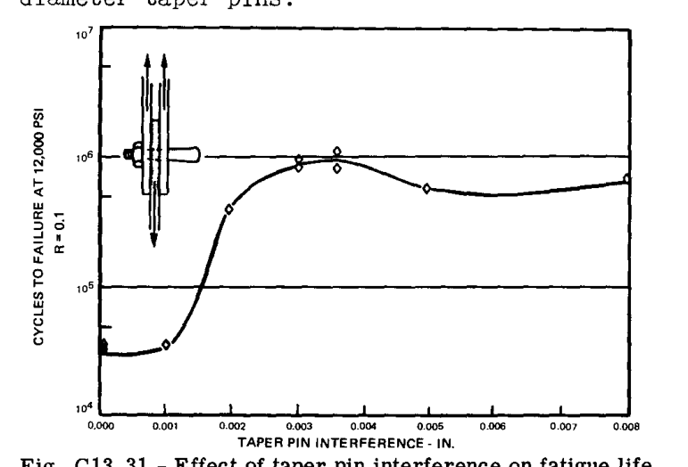

Fig. C13.31 - Effect of taper pin interference on fatigue life of small lugs. (from Ref. 21)

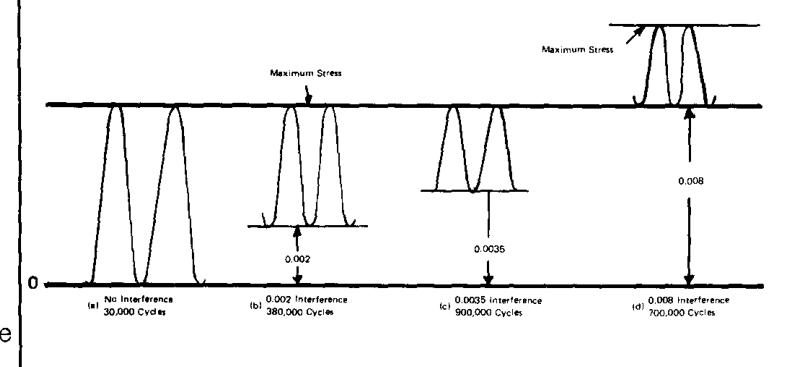

Fig. C13.32 - Schematic diagrams of stress cycle for lugs loaded with 3/8-inch diameter taper pins show how fatigue life is affected by interference type fasteners. It is assumed that no increase in maximum stress results from interferences below 0.0035-inch. The amplitude for 0.008-inch interference is the same as for 0.0035-inch interference, however, the maximum stress is raised which accounts for shorter life.

しまりが0、0.002、0.0035、および0.008インチに対応する応力サイクルの概略図を、図 C13.32に示す。0.008インチのしまりに対する振幅は、0.0035インチのしまりに対するものと同じであるが、しまりが大きすぎるために最大応力が増加している。

0.008インチのしまりは、0.0035インチのしまりを使用した場合よりも寿命が短くなったが、それでもしまりがない場合よりも疲労寿命は長く、疲労寿命の向上に対するしまりばめの許容範囲が広いことを示している。しかし、過度なしまりは、繊維方向に対して好ましくない方向にファスナーが取り付けられた場合に、応力腐食を誘発することになる。

前述の議論は、最大0.010（0.008 in./in.）までのしまりを使用した、幅3.75インチのラグに関する試験によってさらに裏付けられている。穴の直径は1.25インチであり、理論上の応力集中係数は3.5であった。肉厚が1/4および1/8インチの硬化鋼製ブッシュが、ゼロから0.010インチまでの様々なしまり量で圧入された。ブッシュには、ラグからの材料の押し出しなしに圧入できるように、10度の面取りが施された。圧入後、面取りされた端部は削り落とされた（図 C13.33を参照）。

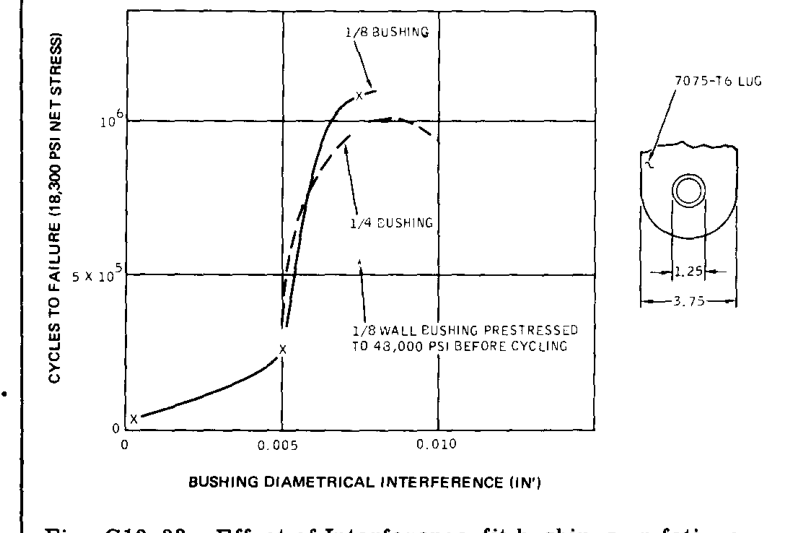

Fig. C13.33 - Effect of Interference-fit bushings on fatigue life of lugs (30).

図 C13.34は、様々な予荷重の後に20 ksiの総面積応力でサイクルさせた、小ラグの寿命を比較したものである。これらの試験片は、荷重を伝達するためにテーパーピンの代わりにテーパーボルトが使用された点を除いて、図 C13.31で使用されたものと同じである。ここでは、予荷重がない状態（20 ksiの予荷重はサイクル応力と同じ）において、寿命が約30,000サイクルから500,000サイクルに増加したことがわかる。30 ksiの予荷重（サイクル応力より10 ksi高い）では、0.003インチのしまりを持つ試験片には明らかな変化は見られなかったが、しまりのないラグにはわずかな向上が見られた。予荷重が40 ksiに達する頃には、しまりのある試験片とない試験片の間には事実上差がなくなっていた。換言すれば、残留圧縮応力の増加が、しまりによる利点を相殺したのである。これは、50 ksiの予荷重まで当てはまる。ここでは、ネット面積の決定が困難な構造継手を模擬するために、総面積応力が使用されている。

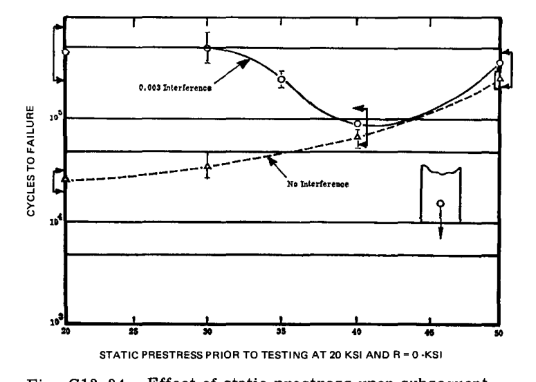

Fig. C13.34 - Effect of static prestress upon subsequent fatigue life of 7075-T6 lugs cycled at 20 ksi gross stress, R = 0(31)

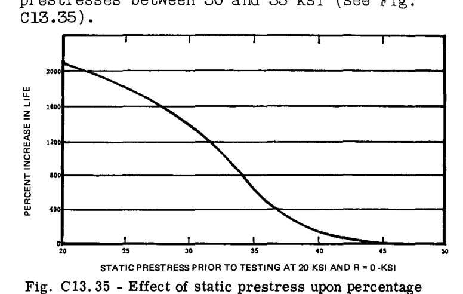

Fig. C13.35 - Effect of static prestress upon percentage life increase produced by using tapered bolts.

比率ベースで見ると、しまりのない試験片の寿命が向上したため、テーパーボルトの有益な効果に対する最大の損失比率は、30から35 ksiの間の予荷重で発生しているようである（図 C13.35を参照）。

## A13.5.7 剛性と残留応力の結合

しまりばめファスナーを使用する試験片の寿命に対する予荷重の影響を示す目的は、実際の稼働において高い荷重が加わった場合に、本質的に同様のことが起こり得ることを読者に知らせるためである。これは、もしそのような応力が実際に稼働中に発生した場合、しまりばめファスナーを使用する主な利点は、高荷重に遭遇する前に消費される寿命の割合に対して発揮されることを意味している。実際、航空機によっては、しまりばめファスナーによって提供される予荷重を緩和するほど十分に高い荷重を一度も経験しない場合がある。しかし、ほとんどの設計は、高荷重が寿命の比較的早い段階で発生するという仮定のもとで行われる必要があり、実際、稼働中の航空機がそのような荷重を受けない場合でも、試験機は受けることになる。したがって、設計者は特別な予防措置が取られない限り、局部的な降伏を引き起こすのに十分な高い荷重を含む、特定の試験荷重セットに対して航空機を設計することを契約上義務付けられている。

高荷重によるしまり緩和の問題に対する解決策は、何が起こるかをおおむね再現することによって視覚化することができる。図 C13.36は、図 C13.34のように予荷重をかけた後の、20 ksiにおける応力サイクルの概略を示している。ここでは、しまりのない試験片の応力サイクルは、図 C13.10のノッチなしS-N曲線を使用し、予荷重後の寿命に適合する応力範囲（この場合は58 ksi）と適切な応力比を使用して決定される。58 ksiの応力範囲は、未使用の試験片において $R = 0$ でサイクルさせたときの元の寿命から求められたものであり、残留応力が存在しないことを前提としている。その後、例題(1)のStep 4および5と同様の試行錯誤の手順が使用される。

しまりが0.003インチの試験片に対する応力は、しまりのない試験片に対する $S_{max}$ を使用し、交点またはS-N曲線と適切な寿命から応力比を決定することによって求められる。試験寿命に適合させるためには、曲線間を補間する必要がある。しまりのみによって荷重時よりも高い応力が生じたと仮定した場合、しまりのある試験片とない試験片で $S_{max}$ が同じであるという仮定には誤差が生じる可能性がある。しかし、そのような誤差は、図説の目的には影響しない。

図 C13.36の概略図は、予荷重の増加に伴って残留圧縮応力が徐々に増加することを示している。これにより、しまりのない試験片の寿命は向上し、0.003インチのしまりを持つ試験片の寿命は、40 ksiの予荷重の後に86,000サイクルの低値に達するまで低下する。その後、両方のタイプで寿命が向上する方向にトレンドが反転する。おそらく、有益な効果は、50 ksiの予荷重の後に消失するはずであるが、しまりばめによってもたらされる横方向の拘束により、ある程度の利点は残るかもしれない。いずれにせよ、寿命の差は、しまりによるいかなる向上も無視できるほど十分に小さい。

ここで、図 C13.36 (d)の $-36$ ksiの残留応力を考慮すると、残留応力を変化させることなく、50 ksiの予荷重を再付与することができると考えられる。また、しまりばめファスナーを取り付ける前に、コイニング（圧痕加工）やその他の方法によって $-36$ ksiを導入することも可能であったと考えられる。これは、このような方法で製造された構造物は、その後の寿命の低下を経験することなく、稼働中に遭遇する高い荷重に耐えることができることを意味する。

コイニングを施したしまりばめファスナータイプの構造は、過大応力による損傷を防止するだけでなく、実際の寿命を向上させる。図 C13.10のS-N曲線を使用して、

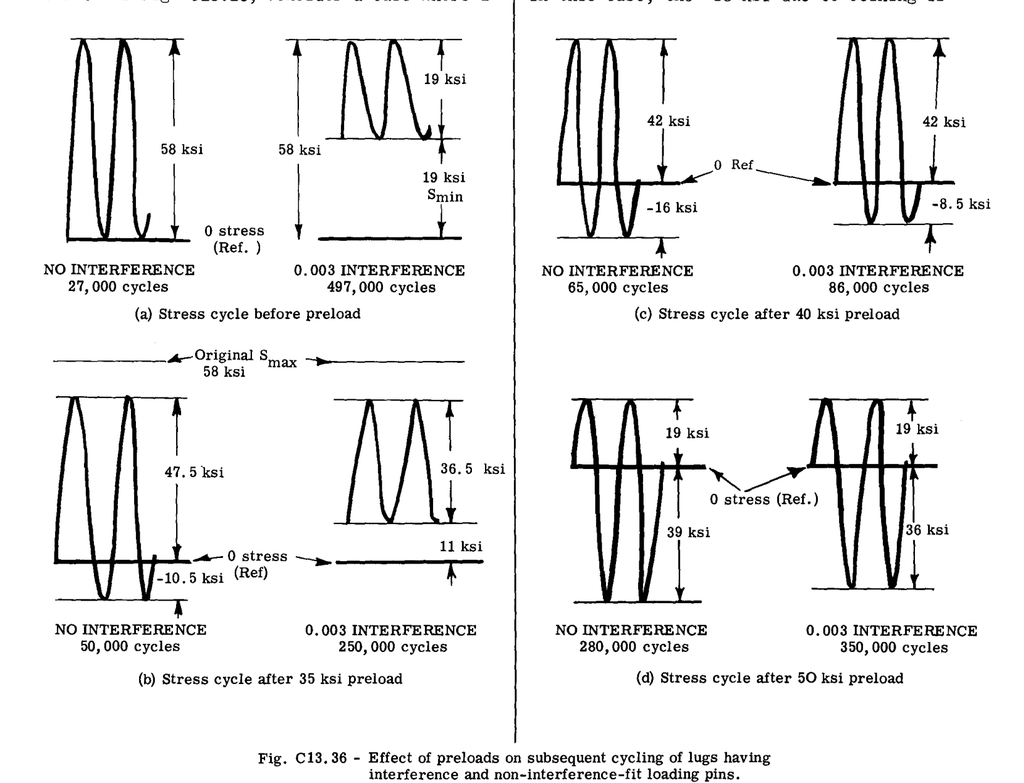

Fig. C13.36 - Effect of preloads on subsequent cycling of lugs having interference and non-interference-fit loading pins.

$R = 0$ 、応力70 ksiにおいて、構造物が11,000サイクルで破損するケースを考える。S-N曲線から、応力集中部における実際の応力は約70 ksiであったに違いないようである（11,000サイクルおよび $R = 0$ を参照）。もし、実際の応力サイクルが $R = +0.5$ になるように、破損箇所にしまりばめタイプのファスナーを使用することができれば、寿命は60,000サイクルに向上する。

しまりばめファスナーを使用する代わりに、部品にコイニングを施して $-35$ ksiの残留圧縮応力を生じさせたと仮定する。同じ荷重条件に対する応力は、 $\pm 35$ ksi（やはり70 ksiの範囲）となり、その結果寿命は55,000サイクルとなる。これは、単にしまりばめファスナーを使用する場合と比較して、特段の向上ではない。

しかし、しまりばめファスナーを使用することに加えて部品にコイニングを施した場合、寿命は、図 C13.10における35 ksi、 $R = 0$ の応力に対して得られる約700,000サイクルとなる。この場合、コイニングによる $-35$ ksiはしまりばめファスナーによって受け持たれるため、応力範囲は35 ksiとなる。これらを図 C13.37に概略的に示す。

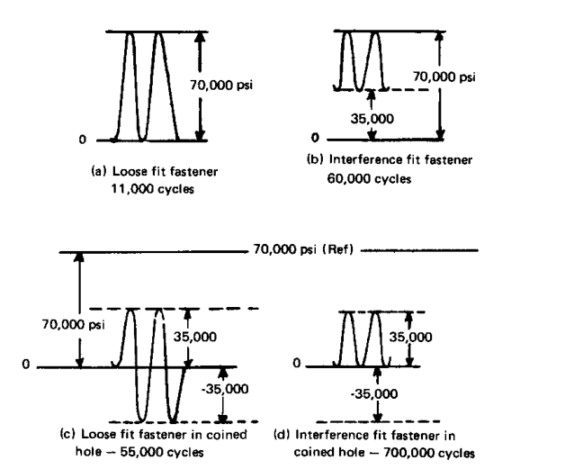

Fig. C13.37 - Diagrams show comparison and improvement in fatigue life obtained with interference fasteners, coining, and combined coining and interference.

静的および疲労特性について上述した内容は、残留圧縮応力、追加された剛性、および残留応力と剛性の組み合わせの効果を説明するためのものである。剛性に関する議論は、ボルトの締め付けおよびしまりばめファスナーの効果をカバーした。

ボルトを締め付けるケースでは、締め付けによって導入される予荷重により、ボルトが当接材料によって提供される追加の剛性を利用できるようになることが示された。しまりばめは穴の縁に周辺引張応力を発生させるが、ファスナーによってもたらされる追加の剛性が応力振幅を低減するため、有益である。

コイニングは、好ましい残留応力を導入する方法として説明された。コイニングは通常、一種のリングステーキング（輪状かしめ）と考えられているが、マンドレル操作による穴の内部のバニシング加工などの他の方法は、少なくとも現在の技術水準ではテーパー穴には適用できない。前述の利点を達成するためには、ストレートファスナーでしまりを得る方法、またはテーパー穴をコイニングする方法が必要である。

テーパー穴をコイニングする1つの方法は、通常の取り付けを行う前に、所定量の永久ひずみを達成するためにテーパーマンドレルを過剰に押し込むことである。現在、これは一般的な実用例ではない。

最近まで、残留圧縮応力を導入することを明確に目的として設計されたファスナーは存在しなかった。新しく開発されたファスナーの断面を図 C13.38に示す。(32) ファスナーは従来の鋲（リベット）とほぼ同様に絞り込まれる（バックされる）が、頭部は表面と面一になるように埋め込まれる。

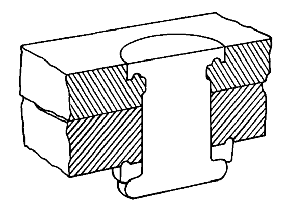

Fig. C13.38 - Newly developed fastener that coins

特別な特徴は、頭部の周囲にあるリップであり、これはファスナーが材料に埋め込まれる際に穴をコイニングする。押し出された材料は、頭部の下にある環状の溝およびシャンクの縮小部に沿って流れ、これによりファスナーの頭部と締結される材料が構造の不可欠な一部となる。これにより、まるで穴をまたいでホッチキスの針が打ち込まれたかのように、穴の変形が多かれ少なかれ減少する（これについては後述する）。対応する応力減少は現時点では分かっていないが、疲労データは、コイニング、荷重伝達、およびしまりばめの組み合わせが疲労寿命の向上に大きく貢献することを示している。しまりは、ファスナーの膨張と、コイニングの結果としてのシャンクへの金属の流れによって達成される。

アルミ製リベット、テーパーボルト、およびStress Pins*で締結された、1.5のドッグボーン試験片の疲労強度を比較したS-Nデータを、図 C13.39に示す。ここでは、極端に高い荷重レベルを除いて、Stress Pinsを使用することによって寿命が大幅に向上していることがわかる。テーパーボルトを使用した試験片の曲線と、アルミ製リベットを使用した試験片の曲線は、低い荷重レベルにおいて収束するように見える点が興味深い。この理由は、テーパーボルトを使用した試験片に使用されたしまりが、

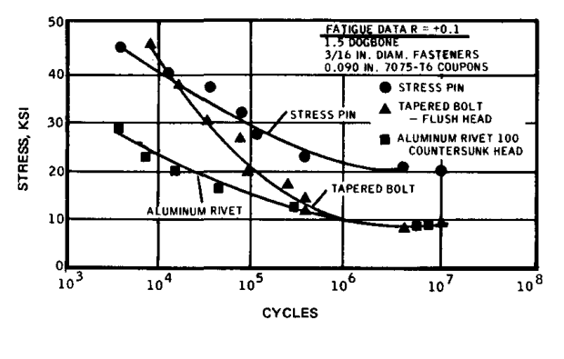

Fig. C13.39 - S-N curves showing fatigue strengths of specimens fastened with countersunk aluminum alloy rivets, tapered bolts, and Stress Pins.

- Standard Pressed Steel Co.（ペンシルベニア州ジェンキンタウン）によって開発されたファスナーの商標名。

低い荷重レベルにおいて実際に応力を増加させたためである。しかし、この領域における損傷の割合は、高い荷重レベルで経験されるものと比較して小さいことが後述される（セクション C13.6を参照）。より低いしまりを使用すれば、低荷重における寿命は向上し、高荷重における寿命は低下し、正味の結果として稼働寿命（すべての荷重タイプの関数である）が短縮されることになる。もししまりがより低ければ、テーパーボルトを使用した試験片の曲線は、おそらくリベットを使用した試験片の曲線とStress Pinsを使用した試験片の曲線のほぼ中間に位置していたであろう。

図 C13.40に示されている1.5ドッグボーン試験片について一言説明する。この特定の構成の目的は、航空機の主翼におけるスパーと外板の接合を模擬することであり、外板における軸応力の約50%は、ファスナーを介してウェブから伝達される荷重によるものである。しかし、ひずみゲージによる測定では、テーパーボルトを使用した試験片およびStress Pinsを使用した試験片の場合、ウェブを代表するハーフドッグボーンからフルドッグボーンへ伝達される荷重はわずか40%であることが明らかになった。アルミ合金製リベットを使用した試験片に対する伝達率は26%であった。このような試験片を使用する特別な利点は、試験片あたり1つのファスナーしか必要としない点である。試験片の完全な説明は、文献32に記載されている。

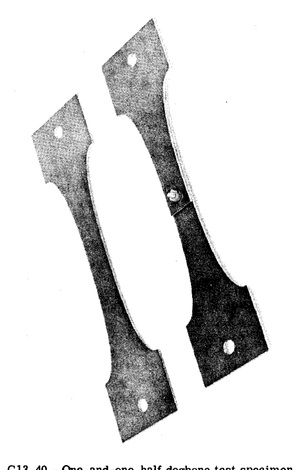

Fig. C13.40 - One-and-one-half dogbone test specimen simulates spar-to-web attachment.

## A13.5.8 ファスナーにおける荷重軽減

これまでは、応力集中部における応力を「許容する」方法について議論してきた。より良い方法は、重量を増加させることなく可能であれば、応力を低減することである。以下は、実証されており、重量をほとんどあるいは全く増加させない（時には重量が削減される）方法である。

### 荷重の再分配

ほとんどの機械的に締結された継手において、応力集中は、オープンホールのものとピン荷重ホールのもののほぼ中間に位置する。これは、これらの継手（ラグを除く）が通常、複数のファスナーを組み込んでいるという事実に起因する。これらのケースでは、荷重はファスナー間で均等に分割されない。

[figure not shown]

Fig. C13.41 - Photoelastic model showing load distribution between fasteners in a clevis joint.

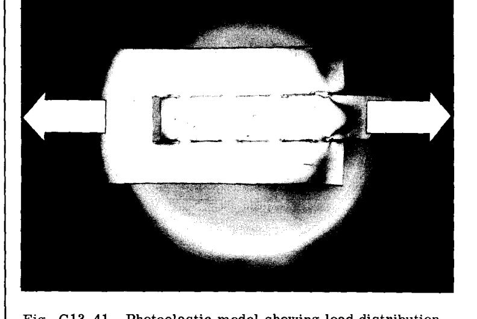

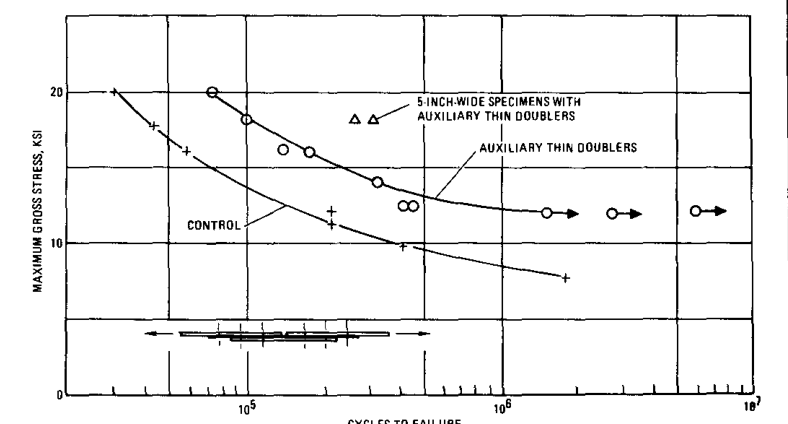

Fig. C13.43 - Effect of auxiliary thin doubler on fatigue strength of 2024-T3 aluminum alloy single-shear butt joints.

### 軸応力と曲げ応力の分離

航空機構造は空気力学的な平滑性のために片面せん断（シングルシヤ）継手を採用しているため、継手における荷重伝達による応力に加えて、曲げ応力が発生する。これは、図 C13.44に示されている片面せん断突合せ継手において説明されており、ダブラーの縁に打ち込まれたリベットにより、寿命が5倍に延びている。ここで、縁に打ち込まれたリベットはクランプ力以外の荷重を負担することができず、荷重を受けるリベットを曲げ応力から解放している。(34) ネストされたアングル試験片は、縁に打ち込まれたリベットの助けなしに、可能な限り曲げを排除するように設計された。曲げの影響は、重ね合わせ（ラップ）継手においてさらに顕著である。このため、応力が極めて低い場合を除き、重ね合わせ継手は可能な限り避けるべきである。

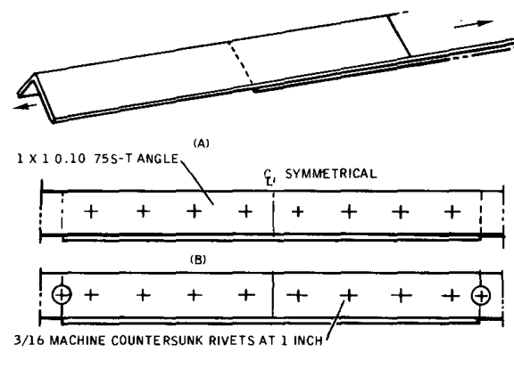

Fig. C13.44 - Edge driven rivet improves fatigue strength of single-shear butt joints.

### スカルプチャードスキン

プロファイルミーリング（倣い削り）の出現に伴い、重量を削減するために応力の低い領域から材料を削り落とし、接続部（スプライス）に全厚の材料を残すことが一般的な実務となっている。このようにして、接続部の隆起部（ランド）や他の重大な領域を除いて、航空機の主翼外板全体を削り出すことができる。

このような環境において、構造物から集中を完全に排除することは不可能であるが、接続領域における厚肉のランドは、他の方法で可能であるよりも高い応力で残りの領域を機能させることを可能にする。

隆起したランドは、機械加工された外板と母材との接合部に隅肉（フィレット）を伴うため、隅肉における応力が、保護されているファスナー穴におけるものよりも悪化する状況が生じる可能性がある。これは、フラッシュ継手の片面せん断取り付けによって発生し、ランドの厚さが増加したときに外板とダブラーの重心を隔てるモーメントアームの増加によって誇張される曲げ応力を導入する。さらに、荷重が増加するにつれてある程度の整列（アライメント）が発生するため、軸応力に対する曲げ応力の比率は荷重に比例しない。したがって、隅肉における応力集中の影響は荷重に関連しており、構造設計において考慮されなければならない。

代表的な例は、等しい厚さの外板とダブラーを持つ片面せん断突合せ継手である。ここで、曲げ応力のみは、荷重 $P = 0$ の時点で $3 P / A$ となる。荷重が増加すると、外板とダブラーは整列しようとするため、最終的には荷重の増加によって曲げによる応力は増加しなくなる。確かに、全断面積が降伏する頃には、曲げによるひずみに大きな差が存在する場合でも、応力は $P / A$ であると仮定することができる。図 C13.45は、等しいランドとダブラーの厚さを持つ7075-T6アルミ合金継手に対する、応力補正された集中係数を示している。(36) これらの曲線は、計算された曲げ応力と軸応力の比率に、図 C13.46に示されている応力集中係数を乗ずることによって得られた。計算値は、電気抵抗ひずみゲージを使用して実験的に検証された。

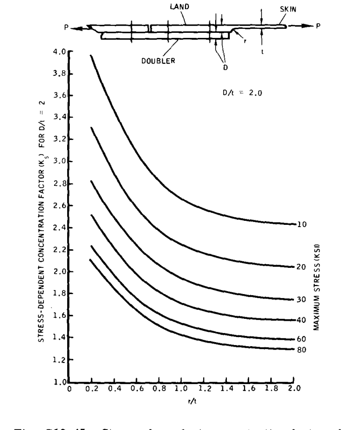

Fig. C13.45 - Stress-dependent concentration factors for fillets in landed structures having equal land and doubler thicknesses.

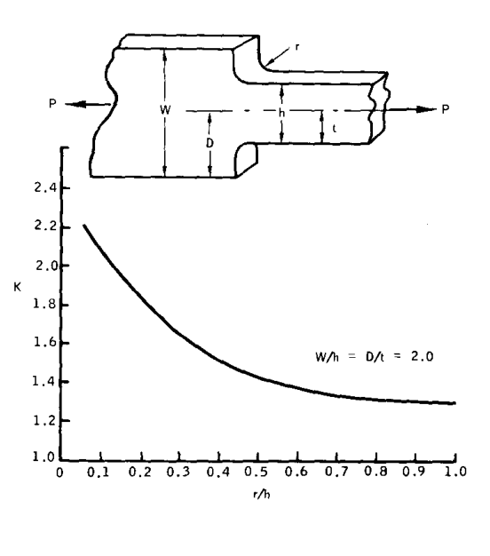

Fig. C13.46 - Stress Concentration for Bar with Fillets Loaded in Tension–D/t = 2 –(Taken from Ref. 6)

前述の内容から、さらに大きな半径を使用すれば、応力をさらに低減できると考えられる。しかし、必要とされる量だけ応力を低減するのに十分な大きさの半径を使用するスペースがない場合がある。そのような場合、図 C13.47に示されているような直線群の交差によって生成される可変半径は、応力を低減する。(37) しかし、スペースが許せば、図 C13.48に示されているように、垂直軸および水平軸に不等間隔の分割を使用することにより、応力をさらに大幅に低減することができる。

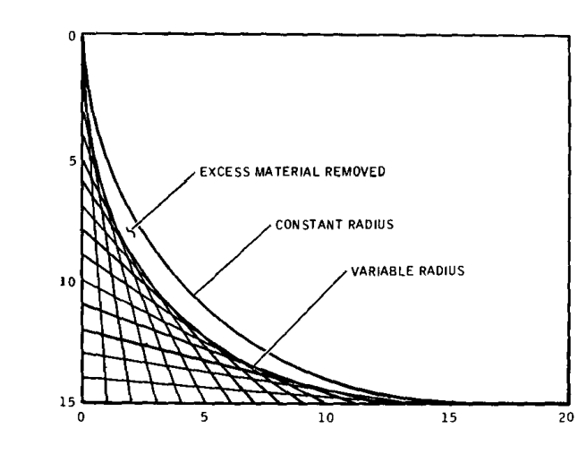

Fig. C13.47 - Variable-radius fillet generated by intersections of straight lines removes material while reducing stress.

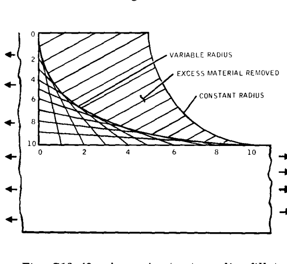

Fig. C13.48 - Approximate streamline fillet

この概念は、図 C13.49 (a)に示されているようなバーにおける応力を視覚化することによって、より容易に理解できる。バーが引張状態にあるとき、ひずみは元の長さに対する伸びとして次のように定義される：

$$\epsilon = \frac{\Delta l}{l}$$

しかし、バーが図 C13.49 (b)に示されているように180度曲げられたとき、曲げ角度は計算上キャンセルされ、次のようになる：

$$l = \pi R$$

（長さは中立軸で変化しないと仮定）、および

$$\Delta l = \pi \left(R + \frac{h}{2}\right) - \pi R = \pi \frac{h}{2}$$

（中立軸と周辺部の長さの差）。

$$\epsilon = \frac{\Delta l}{l} = \frac{\pi (h/2)}{\pi R} = \frac{h}{2R}$$

（または、周辺部と中立軸におけるひずみの差）。

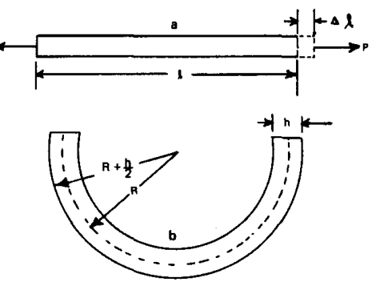

Fig. C13.49 - Strain in bar at (a) which is loaded in tension is found by dividing elongation by original length. When the bar is bent as shown at (b) strain equals h/2R.

したがって、桁方向のランドが追加されているか否かに関わらず、外板は同じ伸びを示す。このような場合、ランドによって外板の厚さを2倍にしても、最初に予想されるようにはファスナー穴における応力を半分にすることはできない。しかし、ランドは余分な支圧面積を提供するため、そうしなければ支圧面の代わりに鋭いエッジを残すことになる、皿穴ファスナーを使用することを可能にする。穴の間のランドから材料が除去されない限り、応力の軸方向成分は全く同じになる。換言すれば、穴における変形を減少させるためには、集中部から離れた領域の材料をより大きく変形させる必要がある。

上記は、すべての設計において従うべき基本原則を示している。

**応力集中部における応力は、集中部から離れた場所から材料を除去することによって低減できる。**

したがって、補助的なダブラーのケース（図 C13.43を参照）では、最初と2番目のファスナー列の間でダブラーから材料を除去することによって、同じ効果を達成できたはずである。改良された隅肉のケース（図 C13.47を参照）では、応力を低減するために材料を除去できることがわかる。

# A13.6 累積疲労被害

## A13.6.1 はじめに

一定の振幅でサイクルさせた場合、構造物または試験片の寿命は、S-N曲線またはLoad-N曲線によって表すことができることを見てきた。しかし、実際の稼働においては、各飛行においてランダムに混合された荷重が発生し、2つとして全く同じ飛行は存在しない。

各飛行が変化するだけでなく、宇宙航空構造物は、時間間隔にわたる使用の観点から、それぞれ異なる要求寿命を持っている。飛行体が耐えるべき寿命の例を表IIIに示している。(38) ここでは、寿命が20年からわずか1分程度まで変化することがわかり、民間航空機の20年の寿命は50,000時間の飛行に解釈される。これは、製造業者が設計および試験によって、構造物が50,000時間の飛行に等しい累積的な影響を持つ荷重に耐えることを実証しなければならないことを意味する。軍用機では、戦闘機の3000時間から練習機の30,000時間までの要求寿命を持っている。

## A13.6.2 荷重

飛行データは、通常、航空機の重心（G.G.）付近に設置された計数加速度計によって得られ、このような情報は、図 C13.50に突風荷重に対して示されているようなオジブ曲線の形式でプロットされる。(39) さらに、マニューバ（操縦）、グランド・エア・グランド（G.A.G.）、着陸、および地上滑走（タクシー）荷重が追加されて、完全な荷重スペクトルが作成される。

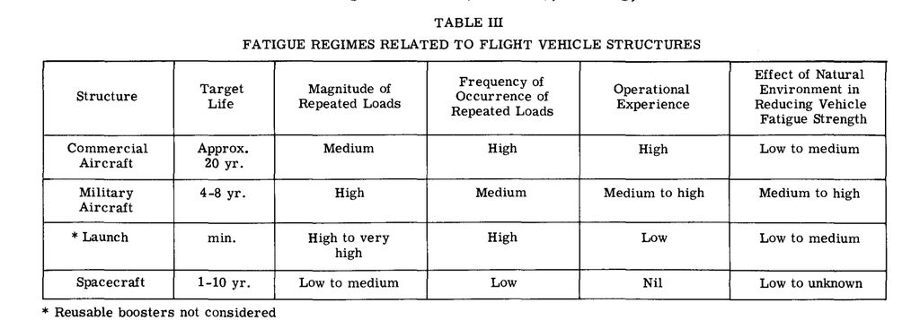

TABLE III - FATIGUE REGIMES RELATED TO FLIGHT VEHICLE STRUCTURES

設計目的の実際の荷重は、速度、空気力学、剛性、および特定の航空機の様々な他の特性に関連しているため、通常は契約機関との合意によって規定される。特定の航空機に対する荷重は、想定される運航タイプおよび飛行経路に大きく依存するため、一般的には、航空機フリートの中でより過酷な条件を含む一連の条件を使用することが一般的である。それにもかかわらず、ある航空会社は疲労問題を経験する一方で、同じメーカーの航空機を使用する別の航空会社は全く問題を経験しない場合がある。いずれにせよ、設計者は、必要な等価時間数にわたって模擬的な実働荷重試験に合格する構造物を設計しなければならない。

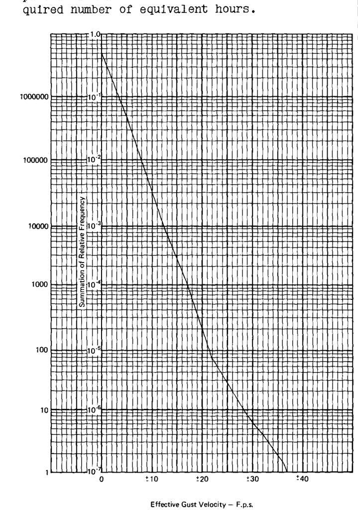

Fig. C13.50 Ogive curve from Ref. 39

設計および試験に使用される荷重は、1つの飛行条件の最も過酷な状態が、他の過酷な条件とブレンドされてすべての条件の複合体となるように妥協が行われるため、実際の稼働荷重を反映していない場合がある。

一般に、戦闘機は突風よりも操縦および着陸条件においてより厳しくなる。一方、輸送機は突風荷重に対してより厳しくなる。表IVは、戦闘機、哨戒機、多目的機、および輸送機がそれぞれクラスA、B、C、およびDに分類される、様々な軍用機に対する操縦荷重スペクトルを示している。(40)

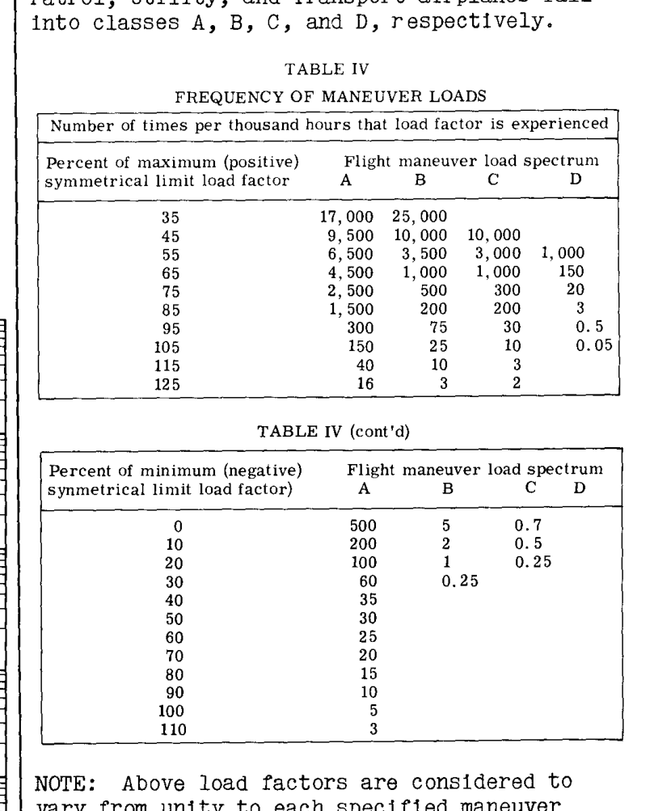

TABLE IV - FREQUENCY OF MANEUVER LOADS

上記の荷重には突風、着陸、または地上滑走荷重は含まれていないが、以降の例題において役立つ。突風の影響は、特定の航空機の個別の特性に大きく依存することに注意する必要がある。突風速度（図 C13.50を参照）の荷重倍数への変換は、関係する個々の航空機には適しているが、他の航空機に対しては誤解を招く可能性がある。

表IVの荷重は、一見厳しそうに見えるが、このようなスペクトルを使用した疲労試験に合格した航空機は、疲労問題をほとんど引き起こしていない一方で、より緩やかな荷重を使用した航空機は、すべての航空機が同じ静的要件を満たしていたにもかかわらず、多くの問題を引き起こしていることから正当化される。

高荷重は寿命を向上させることも、あるいは低下させることもある。これについては、A13.6.4で説明する。

## A13.6.3 寿命の予測

累積疲労被害は、各サイクルごとに追加される、繰り返しの応力による劣化として定義することができる。もし航空機が1つのポイントにおいてのみ厳しく、高荷重による残留応力やファスナーの緩みがその後の寿命に影響を与えないと仮定した場合、ある荷重レベルで寿命の50%が消費されたならば、破損が発生する前に、任意の荷重または荷重の混合において消費できる残りの寿命は50%であるはずである。

1923年にパルムグレンによって最初に提案された(41)部分的な損傷を累積する方法は、ミルトン・マイナーによる論文(42)がその方法を実証する多大なデータを提示するまで、一般的な使用には至らなかった。

一般に、この方法は、構造物が応力 $S_1$ における荷重に対して $N_1$ サイクルで破損し、応力 $S_2$ において $N_2$ サイクル、および応力 $S_n$ に対応する $N_n$ サイクルで破損するとした場合、次のときに構造物が破損することを提案している：

$$\sum \frac{n}{N} = 1$$

ここで、 $n_1, n_2, n_n$ は、それぞれの応力レベルにおいて消費された部分的な寿命である。

この方法は業界全体および様々なサービスにおいて依然として使用されているため、その使用方法の例をここに提示する。しかし、読者は、これが依然として受け入れられている方法である一方で、関与する構造物のタイプに関して考慮がなされる必要があることを心に留めておかなければならない。この方法は、オープンノッチ（開孔、隅肉半径など）を伴うケースに対しては通常保守的であるが、リベットが充填された穴を持つ構造物や、しまりばめファスナーを使用する構造物については、スペクトルにおける最高荷重がその後のより低い応力における性能を向上させるか、あるいは損なうかを批判的に検討する必要がある。ラグに対する予荷重の影響に示されているように（図 C13.34を参照）、予荷重がファスナーを緩めるようなものである場合、予想される寿命の半分以上が失われる可能性がある。

総面積に基づいて制限応力が30 ksiである、4000時間の戦闘機を考える。表IVから、まず規定された荷重に対応する応力を計算する。簡単にするために、荷重は1Gの代わりにゼロを基準とし、各荷重サイクルのゼロへの延長が、省略された荷重に等しい損傷を生じさせると仮定して、負の荷重を省略する。

さらに、構造物の等価応力集中係数は、総面積に基づいて3.1であると仮定する。これにより、 $R = 0$ における穴ノッチ試験片のS-N曲線を使用することができる（図 C13.51を参照）。ここで、単純に

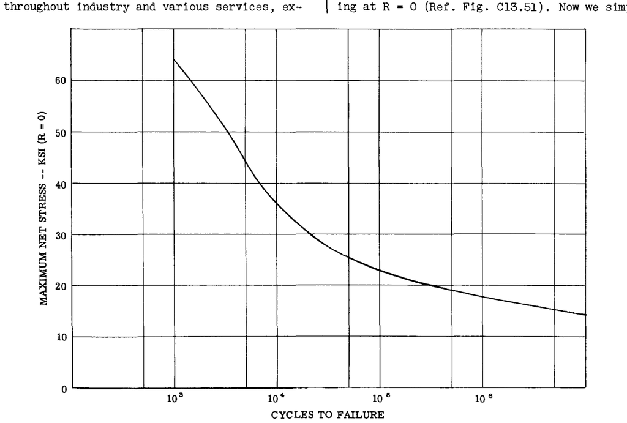

Fig. C13.51 S-N Curve for 7075-T6 Aluminum Alloy – Kt = 3.1 (gross area)

各応力レベルにおける寿命（ $N$ ）を記録し、表Vに示されているように $n/N$ の比率を計算する。インクリメンタルな損傷の合計は0.11266となり、したがって寿命は $1 / 0.11266 = 8,876$ 時間、有効数字を考慮しておよそ8,900時間となる。

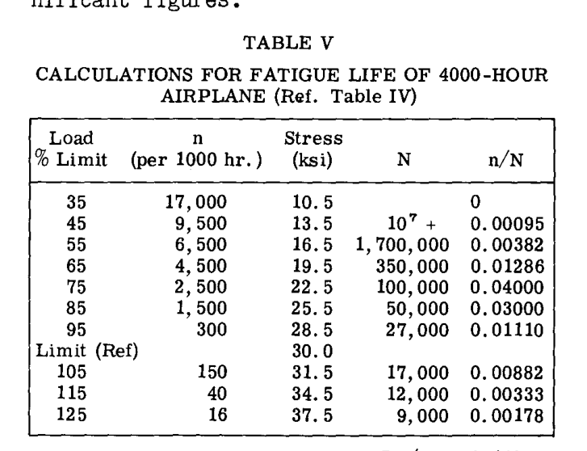

TABLE V - CALCULATIONS FOR FATIGUE LIFE OF 4000-HOUR AIRPLANE (Ref. Table IV)

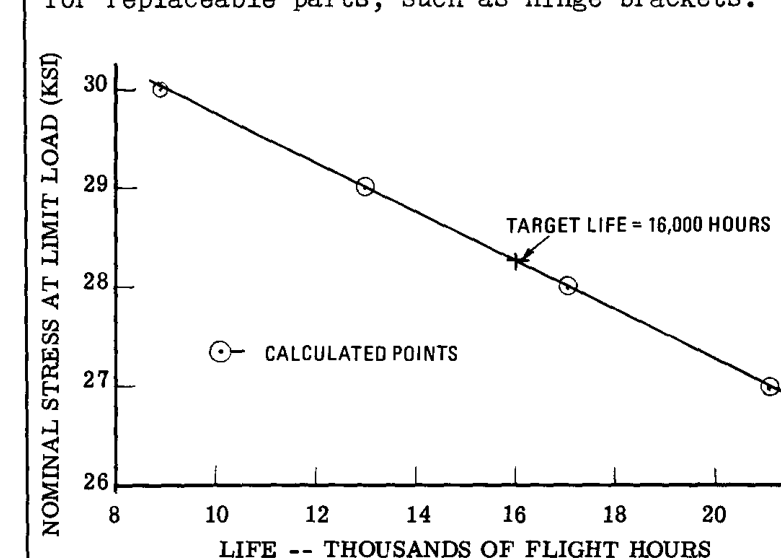

Fig. C13.52 Stress at limit load vs. valculated hours of flight (Ref. Table IV, Spectrum A, positive loads only)

4のばらつき係数（スキャッターファクター）を考慮すると、計算された寿命は16,000時間でなければならない。したがって、応力集中を低減することによって応力を低減できないと仮定した場合、30 ksiの制限応力という仮定は高すぎたことになる。現在の問題は、必要とされる応力低減を「推測」することである。差し当たり、制限応力における応力の低減は、30 ksiの制限応力に対応する寿命よりも、16,000 / 8,876大きい寿命におけるノッチ付き試験片の寿命に比例すると仮定する。このケースでは20,000サイクルである。したがって、次のようになる：

$$1.802 \times 20,000 = 36,040\text{ サイクル}$$

これに対応する最大応力は27.0 ksiとなる。表Vに示されているものと同じ手順を使用して、寿命は約21,000時間であると決定される。28 ksiおよび29 ksiの制限応力に対する連続的な計算により、それぞれ17,000時間および13,000時間の寿命が得られた。制限応力と計算された飛行時間の関係をプロットすると、図 C13.52に示されているように直線が得られる。これから、制限荷重における許容応力は28.3 ksiであると補間される。

上記の計算は、データのソースから正当化されるよりも高い精度を暗示しているが、何らかの基準に基づいて作業する必要があり、それが設計におけるばらつき係数の要件の理由である。契約機関によっては、最終的に製造された航空機は、4寿命分の等価な模擬実動荷重試験を受けなければならない。試験がマイナーな破損なしに完了することはほとんど期待できないが、設計者は、早期の破損が発生した場合のペナルティがどのようなものであるかを認識しておく必要がある。ここでいうペナルティとは、不具合の改修費用や時間の損失を指す。したがって、設計者は、ヒンジブラケットなどの交換可能な部品よりも、主翼スパーの設計においてより保守的であることが求められる。

上記では、利用可能な試験データがあるため、 $K_t = 3.1$ と仮定した。しかし、多くの航空機部品は3.1をはるかに超える集中を持っており、一部は低い場合もある。上記のように制限応力と寿命の関係をプロットしたことで、任意の応力集中に対する寿命を推定する立場にある。例えば、応力集中が3.1ではなく4.0であった場合、設計応力を単純に 4.0 / 3.1 の比率で低下させる。

上記のようにプロットされた設計応力が直線上に載るかどうかは、主に荷重スペクトルに依存する。しかし、スペクトルが何であれ、計算された寿命をプロットすることにより、設計者は、構造物を疲労要件に適合させるために必要なステップを視覚化することができる。

**問題：** 必要な寿命が50,000時間である場合、表IVのスペクトルDに従って荷重が加えられる航空機の許容制限応力を求めよ。実際の寿命は、ばらつき係数を考慮して200,000時間である必要がある。 $K_t = 3.1$ 、 $R = 0$ 、正の荷重のみとする。